# SLR - Faculty Notebook (Day 1) [v5.0 - 161020]

# 5. Multiple Linear Regression (MLR)

It is used to study the linear relationship between a dependent (target) variable and two or more independent variables. We can use this technique to study the effect of multiple variables on the target variable.

## 5.1 Assumptions Before MLR Model

There are several assumptions of linear regression. We can check two of them before building the regression model. Let us check the following assumptions in this section:

1. Assumption on Dependent Variable
2. No or little multicollinearity

Let us create the dataframes for independent and target variable to check the assumptions of linear regression.

```python
# create dataframe of features by dropping the target variable
# 'axis = 1' drops the corresponding column(s)
df_feature = df_reimb.drop('Total_Reimbursement', axis = 1)

# create dataframe of target variable
df_target = df_reimb['Total_Reimbursement']
```

### 5.1.1 Assumption on Dependent Variable

The assumption for linear regression is that the dependent (target) variable should be numeric. In our dataset, the variable 'Total_Reimbursement' is the target/dependent variable.

```python
# check the data type of dependent variable
df_target.dtype
```

```
dtype('float64')
```

**Interpretation:** The output shows that the data type of target variable is 'float64'. i.e. the dependent variable is numeric.

### 5.1.2 No or Little Multicollinearity

Whenever there are a large number of independent variables present in the dataset, there is a possibility that such independent variables will be strongly correlated. The presence of a strong correlation between the independent variables is called multicollinearity.

The presence of multicollinearity can destabilize the model. Thus, the existence of multicollinearity must be detected and corrected actions should be taken.

If we use dummy variables to encode a categorical variable and do not omit the parent column, then this results in a strong correlation between the dummy variables and the parent column.

#### 5.1.2.1 Correlation Matrix

Let us plot the heatmap to visualize the correlation matrix of the independent variables. The variables with a high correlation may induce multicollinearity in the data.

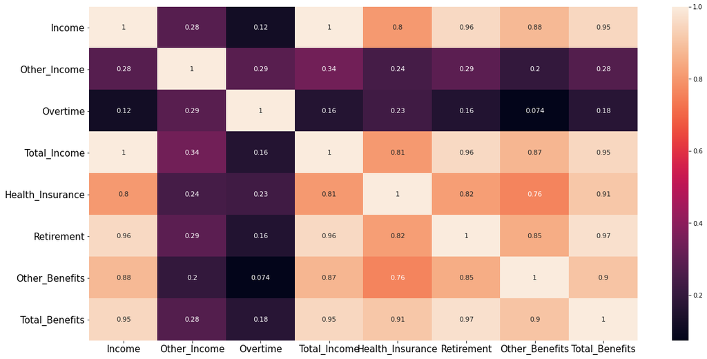

```python
# set the plot size using figure()
# pass width and height in inches to 'figsize'
plt.figure(figsize = (20,10))

# plot the heat map
# corr(): give the correlation matrix
# annot: prints the correlation values in the chart
# annot_kws: used to set the font size of the annotation
sns.heatmap(df_feature.corr(), annot = True, annot_kws = {"size": 11})

# rotation = 'horizontal' rotates the y-axis labels horizontally
# set text size using 'fontsize'
plt.yticks(rotation = 'horizontal', fontsize = 15)
plt.xticks(fontsize = 15)

# display the plot
plt.show()
```

Identify the variables with a correlation greater than 0.8 and less than -0.8.

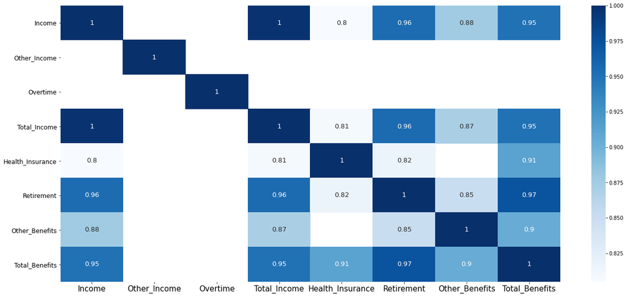

```python
# set the plot size using figure()
# pass width and height in inches to 'figsize'
plt.figure(figsize = (22,10))

# plot the heat map
# corr(): give the correlation matrix
# annot: prints the correlation values in the chart
# annot_kws: sets the font size of the annotation
sns.heatmap(df_feature.corr()[np.abs(df_feature.corr()) > 0.8], annot = True, annot_kws = {"size": 13}, cmap = 'Blues')

# rotate the y-axis labels
# set text size using 'fontsize'
plt.yticks(rotation = 'horizontal', fontsize = 12)
plt.xticks(fontsize = 15)

# display the plot
plt.show()
```

**Interpretation:** The above heatmap, show the variables having a strong positive/negative correlation. The variables with dark shade represent the strong positive correlation.

#### 5.1.2.2 Variance Inflation Factor (VIF)

The Variance Inflation Factor (VIF) is used to detect the presence of multicollinearity between the features. The value of VIF equal to 1 indicates that no features are correlated. We calculate VIF of the numerical independent variables.

Steps to calculate VIF:

1. Regress one independent variable (say V<sub>i</sub>) on all the remaining independent variables (say V<sub>j</sub>, j ≠ i)
2. Calculate R-squared of the regression model
3. Calculate VIF for the variable V<sub>i</sub> using the formula:

   **VIF = 1 / (1 - R-squared)**
4. Repeate the steps 1 to 3 to calculate VIF of each independent variable

```python
# filter the numerical features in the dataset
df_numeric_features_vif = df_feature.select_dtypes(include=[np.number])

# display the first five observations
df_numeric_features_vif.head()
```

|  | Income | Other_Income | Overtime | Total_Income | Health_Insurance | Retirement | Other_Benefits | Total_Benefits |
| --- | --- | --- | --- | --- | --- | --- | --- | --- |
| 0 | 0.979272 | -0.476483 | -0.234449 | 0.921924 | 0.911621 | 1.173963 | 1.141794 | 1.156388 |
| 1 | -1.259481 | -0.588280 | -0.175594 | -1.270526 | -1.504303 | -1.186975 | -1.269380 | -1.374560 |
| 3 | -0.170114 | 0.091140 | -0.431752 | -0.175099 | -1.592864 | -0.037175 | -0.043455 | -0.529238 |
| 4 | -0.264471 | -0.588280 | -0.429539 | -0.306397 | -0.409093 | -0.318044 | -0.263806 | -0.355332 |
| 5 | 0.531722 | 0.015083 | -0.431014 | 0.506445 | 0.989313 | 0.506980 | 0.698624 | 0.726492 |

#### Calculate the VIF for each numeric variable.

```python
# create an empty dataframe to store the VIF for each variable
vif = pd.DataFrame()

# calculate VIF using list comprehension
# use for loop to access each variable
# calculate VIF for each variable and create a column 'VIF_Factor' to store the values
vif["VIF_Factor"] = [variance_inflation_factor(df_numeric_features_vif.values, i) for i in range(df_numeric_features_vif.shape[1])]

# create a column of variable names
vif["Features"] = df_numeric_features_vif.columns

# sort the dataframe based on the values of VIF_Factor in descending order
# 'ascending = False' sorts the data in descending order
# 'reset_index' resets the index of the dataframe
# 'drop = True' drops the previous index
vif.sort_values('VIF_Factor', ascending = False).reset_index(drop = True)
```

|  | VIF_Factor | Features |
| --- | --- | --- |
| 0 | 30075967.183044 | Income |
| 1 | 22042451.424306 | Other_Benefits |
| 2 | 21341383.734145 | Overtime |
| 3 | 16853769.503994 | Other_Income |
| 4 | 11860118.016402 | Total_Income |
| 5 | 10313536.309979 | Health_Insurance |
| 6 | 4396100.420985 | Retirement |
| 7 | 2624112.865499 | Total_Benefits |

The output shows that the variable 'Income' has the highest VIF. Now, we use the `for loop` to find VIF and remove the variables with VIF greater than 10. We set the threshold to 10, as we wish to remove the variable for which the remaining variables explain more than 90% of the variation. One can choose the threshold other than 10. (it depends on the business requirements)

```python
# for each numeric variable, calculate VIF and save it in a dataframe 'vif'

# use for loop to iterate the VIF function
for ind in range(len(df_numeric_features_vif.columns)):

    # create an empty dataframe
    vif = pd.DataFrame()

    # calculate VIF using list comprehension
    # use for loop to access each variable
    # calculate VIF for each variable and create a column 'VIF_Factor' to store the values
    vif["VIF_Factor"] = [variance_inflation_factor(df_numeric_features_vif.values, i) for i in range(df_numeric_features_vif.shape[1])]

    # create a column of variable names
    vif["Features"] = df_numeric_features_vif.columns

    # filter the variables with VIF greater than 10 and store it in a dataframe 'multi'
    # one can choose the threshold other than 10 (it depends on the business requirements)
    multi = vif[vif['VIF_Factor'] > 10]

    # if dataframe 'multi' is not empty, then sort the dataframe by VIF values
    # if dataframe 'multi' is empty (i.e. all VIF <= 10), then print the dataframe 'vif' and break the for loop using 'break'
    # 'by' sorts the data using given variable(s)
    # 'ascending = False' sorts the data in descending order
    if(multi.empty == False):
        df_sorted = multi.sort_values(by = 'VIF_Factor', ascending = False)
    else:
        print(vif)
        break

    # use if-else to drop the variable with the highest VIF
    # if  dataframe 'df_sorted' is not empty, then drop the first entry in the column 'Features' from the numeric variables
    # select the variable using 'iloc[]'
    # 'axis=1' drops the corresponding column
    #  else print the final dataframe 'vif' with all values after removal of variables with VIF less than 10
    if (df_sorted.empty == False):
        df_numeric_features_vif = df_numeric_features_vif.drop(df_sorted.Features.iloc[0], axis=1)
    else:
        print(vif)
```

```
   VIF_Factor        Features
0    1.176818    Other_Income
1    1.107197        Overtime
2    3.914703      Retirement
3    3.699482  Other_Benefits
```

```python
# display the first 5 observations
df_numeric_features_vif.head()
```

|  | Other_Income | Overtime | Retirement | Other_Benefits |
| --- | --- | --- | --- | --- |
| 0 | -0.476483 | -0.234449 | 1.173963 | 1.141794 |
| 1 | -0.588280 | -0.175594 | -1.186975 | -1.269380 |
| 3 | 0.091140 | -0.431752 | -0.037175 | -0.043455 |
| 4 | -0.588280 | -0.429539 | -0.318044 | -0.263806 |
| 5 | 0.015083 | -0.431014 | 0.506980 | 0.698624 |

**Interpretation** Now, we have all the variables with VIF less than 10. So, we can conclude that there is no multicollinearity in the data.  
We will use the above dataframe "df_numeric_features_vif" to build the MLR model with significant variables.

## 5.2 Build the MLR Model

### 5.2.1 MLR Full Model

We use the OLS technique to predict the Total_Reimbursement by considering all the independent features in the data.

#### Filter numerical and categorical variables

```python
# create dataframe of features by dropping the target variable
# 'axis = 1' drops the corresponding column(s)
df_feature = df_reimb.drop('Total_Reimbursement', axis = 1)

# create dataframe of target variable
df_target = df_reimb['Total_Reimbursement']
```

```python
# filter the numerical features in the dataset
# 'select_dtypes' is used to select the variables with given data type
# 'include=[np.number]' will include all the numerical variables
df_num = df_feature.select_dtypes(include=[np.number])

# display numerical features
df_num.columns
```

```
Index(['Income', 'Other_Income', 'Overtime', 'Total_Income',
       'Health_Insurance', 'Retirement', 'Other_Benefits', 'Total_Benefits'],
      dtype='object')
```

```python
# filter the categorical features in the dataset
# 'select_dtypes' is used to select the variables with given data type
# 'include=[np.object]' will include all the categorical variables
df_cat = df_feature.select_dtypes(include=[np.object])

# display categorical features
df_cat.columns
```

```
Index(['Year', 'Type_of_yr'], dtype='object')
```

The OLS method fails in the presence of categorical variables. To overcome this we use (n-1) dummy encoding.

**Encode the categorical variables and create (n-1) dummy variables for n categories of the variables.**

```python
# use 'get_dummies' from pandas to create dummy variables
# use 'drop_first' to create (n-1) dummy variables
encoded_data = pd.get_dummies(data = df_cat, drop_first=True)
```

```python
encoded_data.head()
```

|  | Year_2016 | Year_2017 | Year_2018 | Type_of_yr_Financial |
| --- | --- | --- | --- | --- |
| 0 | 0 | 0 | 0 | 1 |
| 1 | 0 | 0 | 0 | 0 |
| 3 | 0 | 0 | 1 | 1 |
| 4 | 0 | 1 | 0 | 1 |
| 5 | 0 | 1 | 0 | 0 |

#### Concatenate numerical and dummy encoded categorical variables.

```python
# concat the dummy variables with numeric features to create a dataframe of all independent variables
# 'axis=1' concats the dataframes along columns
df_reimb_dummy = pd.concat([df_num, encoded_data], axis=1)

# display first five observations
df_reimb_dummy.head()
```

|  | Income | Other_Income | Overtime | Total_Income | Health_Insurance | Retirement | Other_Benefits | Total_Benefits | Year_2016 | Year_2017 | Year_2018 | Type_of_yr_Financial |
| --- | --- | --- | --- | --- | --- | --- | --- | --- | --- | --- | --- | --- |
| 0 | 0.979272 | -0.476483 | -0.234449 | 0.921924 | 0.911621 | 1.173963 | 1.141794 | 1.156388 | 0 | 0 | 0 | 1 |
| 1 | -1.259481 | -0.588280 | -0.175594 | -1.270526 | -1.504303 | -1.186975 | -1.269380 | -1.374560 | 0 | 0 | 0 | 0 |
| 3 | -0.170114 | 0.091140 | -0.431752 | -0.175099 | -1.592864 | -0.037175 | -0.043455 | -0.529238 | 0 | 0 | 1 | 1 |
| 4 | -0.264471 | -0.588280 | -0.429539 | -0.306397 | -0.409093 | -0.318044 | -0.263806 | -0.355332 | 0 | 1 | 0 | 1 |
| 5 | 0.531722 | 0.015083 | -0.431014 | 0.506445 | 0.989313 | 0.506980 | 0.698624 | 0.726492 | 0 | 1 | 0 | 0 |

**Interpretation:** We can see that the dummy variables are added to the data.

#### Split the data into training and test sets.

```python
# set of independent variables
# create a copy of 'df_reimb_dummy' and store in the dataframe 'X_full'
X_full = df_reimb_dummy.copy()

# dependent variable
# create a copy of 'df_target' and store in the dataframe 'y_full'
y_full = df_target.copy()

# to estimate the regression coefficient, a constant term of '1' needs to be added as a separate column
# 'sm.add_constant' adds the intercept to the model
X_full = sm.add_constant(X_full)

# split data into train subset and test subset
# set 'random_state' to generate the same dataset each time you run the code
# 'test_size' returns the proportion of data to be included in the testing set
X_train_full, X_test_full, y_train_full, y_test_full = train_test_split(X_full, y_full, random_state=1, test_size = 0.3)

# checking the dimensions of the train & test subset
# print dimension of train set
print('X_train_full', X_train_full.shape)
print('y_train_full', y_train_full.shape)

# print dimension of test set
print('X_test_full', X_test_full.shape)
print('y_test_full', y_test_full.shape)
```

```
X_train_full (26320, 13)
y_train_full (26320,)
X_test_full (11281, 13)
y_test_full (11281,)
```

**Build the multiple linear regression model using the OLS method.**

```python
# build a model on training dataset
# fit() is used to fit the OLS model
MLR_full_model = sm.OLS(y_train_full, X_train_full).fit()

# print the summary output
print(MLR_full_model.summary())
```

```
                             OLS Regression Results
===============================================================================
Dep. Variable:     Total_Reimbursement   R-squared:                       1.000
Model:                             OLS   Adj. R-squared:                  1.000
Method:                  Least Squares   F-statistic:                 1.368e+33
Date:                 Fri, 16 Oct 2020   Prob (F-statistic):               0.00
Time:                         15:58:59   Log-Likelihood:             8.6308e+05
No. Observations:                26320   AIC:                        -1.726e+06
Df Residuals:                    26309   BIC:                        -1.726e+06
Df Model:                           10
Covariance Type:             nonrobust
========================================================================================
                           coef    std err          t      P>|t|      [0.025      0.975]
----------------------------------------------------------------------------------------
const                -2.091e-14   1.85e-17  -1128.208      0.000   -2.09e-14   -2.09e-14
Income                   0.3643   1.67e-17   2.18e+16      0.000       0.364       0.364
Other_Income             0.0215   9.42e-18   2.28e+15      0.000       0.021       0.021
Overtime                 0.0122    9.2e-18   1.32e+15      0.000       0.012       0.012
Total_Income             0.3576   1.63e-17    2.2e+16      0.000       0.358       0.358
Health_Insurance         0.0609   1.62e-17   3.77e+15      0.000       0.061       0.061
Retirement               0.1071   2.55e-17    4.2e+15      0.000       0.107       0.107
Other_Benefits           0.0378   1.85e-17   2.04e+15      0.000       0.038       0.038
Total_Benefits           0.0856   1.17e-17   7.34e+15      0.000       0.086       0.086
Year_2016            -8.847e-17   2.93e-17     -3.015      0.003   -1.46e-16    -3.1e-17
Year_2017             3.235e-16   2.34e-17     13.855      0.000    2.78e-16    3.69e-16
Year_2018             2.316e-16   2.25e-17     10.273      0.000    1.87e-16    2.76e-16
Type_of_yr_Financial  1.136e-16   1.86e-17      6.118      0.000    7.72e-17     1.5e-16
==============================================================================
Omnibus:                     1430.668   Durbin-Watson:                   1.954
Prob(Omnibus):                  0.000   Jarque-Bera (JB):              993.559
Skew:                          -0.367   Prob(JB):                    1.78e-216
Kurtosis:                       2.395   Cond. No.                     4.03e+16
==============================================================================

Warnings:
[1] Standard Errors assume that the covariance matrix of the errors is correctly specified.
[2] The smallest eigenvalue is 9.08e-29. This might indicate that there are
strong multicollinearity problems or that the design matrix is singular.
```

**Interpretation:** The R-squared value obtained from this model is 1.0 which means that the above model explains a 100% of the variation in the Total_Reimbursement. But, this can't be possible.

The `Durbin-Watson` test is used to check the autocorrelation between the residuals.

If the Durbin-Watson test statistic is near to 2: no autocorrelation  
If the Durbin-Watson test statistic is between 0 and 2: positive autocorrelation  
If the Durbin-Watson test statistic is between 2 and 4: negative autocorrelation

The `Jarque-Bera` test is used to check the normality of the residuals. Here, the p-value of the test is less than 0.05; that implies the residuals are not normally distributed.

Also, the 'Cond. No' (4.03e+16) represents the `Condition Number (CN)` that is used to check the multicollinearity.

If CN < 100: no multicollinearity.  
If CN is between 100 and 1000: moderate multicollinearity  
If CN > 1000: severe multicollinearity

Thus, it can be seen that there is severe multicollinearity in the data.

#### Predict the Total_Reimbursement using X_test_full

```python
y_pred_full = MLR_full_model.predict(X_test_full)
```

### 5.2.2 MLR Model after Removing Insignificant Variables

Now, let us build the model using the categorical variable and the variables obtained from VIF.

#### Filter numerical and categorical variables

```python
# display numeric features obtained from VIF
df_numeric_features_vif.columns
```

```
Index(['Other_Income', 'Overtime', 'Retirement', 'Other_Benefits'], dtype='object')
```

```python
# filter the categorical features in the dataset
# 'select_dtypes' is used to select the variables with given data type
# 'include=[np.object]' will include all the categorical variables
df_cat = df_feature.select_dtypes(include=[np.object])

# display categorical features
df_cat.columns
```

```
Index(['Year', 'Type_of_yr'], dtype='object')
```

The OLS method fails in the presence of categorical variables. To overcome this we use (n-1) dummy encoding.

**Encode the categorical variables and create (n-1) dummy variables for n categories.**

```python
# use 'get_dummies' from pandas to create dummy variables
# use 'drop_first' to create (n-1) dummy variables
encoded_data = pd.get_dummies(data = df_cat, drop_first=True)
```

#### Concatenate numerical and dummy encoded categorical variables.

```python
# concat the dummy variables with numeric features to create a dataframe of all independent variables
# 'axis=1' concats the dataframes along columns
df_reimb_dummy = pd.concat([df_numeric_features_vif, encoded_data], axis=1)

# display first five observations
df_reimb_dummy.head()
```

|  | Other_Income | Overtime | Retirement | Other_Benefits | Year_2016 | Year_2017 | Year_2018 | Type_of_yr_Financial |
| --- | --- | --- | --- | --- | --- | --- | --- | --- |
| 0 | -0.476483 | -0.234449 | 1.173963 | 1.141794 | 0 | 0 | 0 | 1 |
| 1 | -0.588280 | -0.175594 | -1.186975 | -1.269380 | 0 | 0 | 0 | 0 |
| 3 | 0.091140 | -0.431752 | -0.037175 | -0.043455 | 0 | 0 | 1 | 1 |
| 4 | -0.588280 | -0.429539 | -0.318044 | -0.263806 | 0 | 1 | 0 | 1 |
| 5 | 0.015083 | -0.431014 | 0.506980 | 0.698624 | 0 | 1 | 0 | 0 |

**Interpretation:** We can see that the dummy variables are added to the data.

#### Split the data into training and test sets.

```python
# set of independent variables
# create a copy of 'df_reimb_dummy' and store in the dataframe 'X_signi_var'
X_signi_var = df_reimb_dummy.copy()

# dependent variable
# create a copy of 'df_target' and store in the dataframe 'y_signi_var'
y_signi_var = df_target.copy()

# to estimate the regression coefficient, a constant term of '1' needs to be added as a separate column
# 'sm.add_constant' adds the intercept to the model
X_signi_var = sm.add_constant(X_signi_var)

# split data into train subset and test subset
# set 'random_state' to generate the same dataset each time you run the code
# 'test_size' returns the proportion of data to be included in the testing set
X_train_signi_var, X_test_signi_var, y_train_signi_var, y_test_signi_var = train_test_split(X_signi_var, y_signi_var,
                                                                                            random_state=1, test_size = 0.3)

# checking the dimensions of the train & test subset
# print dimension of train set
print('X_train_signi_var', X_train_signi_var.shape)
print('y_train_signi_var', y_train_signi_var.shape)

# print dimension of test set
print('X_test_signi_var', X_test_signi_var.shape)
print('y_test_signi_var', y_test_signi_var.shape)
```

```
X_train_signi_var (26320, 9)
y_train_signi_var (26320,)
X_test_signi_var (11281, 9)
y_test_signi_var (11281,)
```

**Build the multiple linear regression model using the OLS method.**

```python
# build a model on training dataset
# fit() is used to fit the OLS model
MLR_model_vif = sm.OLS(y_train_signi_var, X_train_signi_var).fit()

# print the summary output
print(MLR_model_vif.summary())
```

```
                             OLS Regression Results
===============================================================================
Dep. Variable:     Total_Reimbursement   R-squared:                       0.962
Model:                             OLS   Adj. R-squared:                  0.962
Method:                  Least Squares   F-statistic:                 8.218e+04
Date:                 Fri, 16 Oct 2020   Prob (F-statistic):               0.00
Time:                         15:58:59   Log-Likelihood:                 5495.0
No. Observations:                26320   AIC:                        -1.097e+04
Df Residuals:                    26311   BIC:                        -1.090e+04
Df Model:                            8
Covariance Type:             nonrobust
========================================================================================
                           coef    std err          t      P>|t|      [0.025      0.975]
----------------------------------------------------------------------------------------
const                   -0.0454      0.003    -17.418      0.000      -0.050      -0.040
Other_Income             0.0563      0.001     42.864      0.000       0.054       0.059
Overtime                 0.0161      0.001     12.692      0.000       0.014       0.019
Retirement               0.7582      0.002    309.327      0.000       0.753       0.763
Other_Benefits           0.2300      0.002     96.794      0.000       0.225       0.235
Year_2016                0.1115      0.004     27.297      0.000       0.104       0.120
Year_2017                0.0989      0.003     30.513      0.000       0.093       0.105
Year_2018                0.0019      0.003      0.603      0.547      -0.004       0.008
Type_of_yr_Financial     0.0019      0.003      0.714      0.475      -0.003       0.007
==============================================================================
Omnibus:                    12755.584   Durbin-Watson:                   1.965
Prob(Omnibus):                  0.000   Jarque-Bera (JB):           939423.249
Skew:                           1.478   Prob(JB):                         0.00
Kurtosis:                      32.118   Cond. No.                         6.05
==============================================================================

Warnings:
[1] Standard Errors assume that the covariance matrix of the errors is correctly specified.
```

**Interpretation:** The R-squared value obtained from this model is 0.962 which means that the above model explains a 96.2% of the variation in the Total_Reimbursement. Also, we can see that the p-value for some variabels is greater than 0.05, we remove such variables and again build the model.

Now, calculate the p-values for each variable and create a list of all insignificant variables in the model.

#### Calculate the p-values to know the insignificant variables

```python
# calculate p-values for all the independent variables in the MLR_model
# create a dataframe containing p-values
# pass the column name to the parameter 'columns'
MLR_pvalues = pd.DataFrame(MLR_model_vif.pvalues, columns = ["P-Value"])

# print the dataframe
MLR_pvalues
```

|  | P-Value |
| --- | --- |
| const | 0.000000 |
| Other_Income | 0.000000 |
| Overtime | 0.000000 |
| Retirement | 0.000000 |
| Other_Benefits | 0.000000 |
| Year_2016 | 0.000000 |
| Year_2017 | 0.000000 |
| Year_2018 | 0.546668 |
| Type_of_yr_Financial | 0.475203 |

**Interpretation:** The above table shows the p-value of each variable. Use this dataframe to identify the significant variables.

#### Create a list of insignificant variables.

```python
# subset the dataframe 'MLR_pvalues' such that the variables will have p-value greater than 0.05
# store the subset of a dataframe to a new dataframe 'insignificant_var'
insignificant_var = MLR_pvalues[1:][MLR_pvalues[1:]['P-Value'] > 0.05]

# get the variable names with p-value greater than 0.05
insigni_var = insignificant_var.index

# convert the variables to the type 'list' using 'to_list()'
insigni_var = insigni_var.to_list()

# print the list of insignificant variables
insigni_var
```

```
['Year_2018', 'Type_of_yr_Financial']
```

Now, build a model after removing the insignificant variables from the data.

Drop the variable `Type_of_yr`, as one category 'Financial' is insignificant. We do not dro the variable 'Year' as only one category out of 4 categories is insignificant.

```python
# drop the insignificant variables from the dataframe 'X_train_signi_var'
# we drop the variable 'Type_of_yr_Financial', as it is insignificant
# 'axis = 1' drops the corresponding column(s)
X_train_signi_var = X_train_signi_var.drop(['Type_of_yr_Financial'], axis=1)

# drop the insignificant variables from the dataframe 'X_test_signi_var'
# 'axis = 1' drops the corresponding column(s)
X_test_signi_var = X_test_signi_var.drop(['Type_of_yr_Financial'], axis=1)

# building a model on training dataset
# fit() is used to fit the OLS model
MLR_model_with_significant_var = sm.OLS(y_train_signi_var, X_train_signi_var).fit()

# print the summary output
print(MLR_model_with_significant_var.summary())
```

```
                             OLS Regression Results
===============================================================================
Dep. Variable:     Total_Reimbursement   R-squared:                       0.962
Model:                             OLS   Adj. R-squared:                  0.962
Method:                  Least Squares   F-statistic:                 9.392e+04
Date:                 Fri, 16 Oct 2020   Prob (F-statistic):               0.00
Time:                         15:58:59   Log-Likelihood:                 5494.8
No. Observations:                26320   AIC:                        -1.097e+04
Df Residuals:                    26312   BIC:                        -1.091e+04
Df Model:                            7
Covariance Type:             nonrobust
==================================================================================
                     coef    std err          t      P>|t|      [0.025      0.975]
----------------------------------------------------------------------------------
const             -0.0444      0.002    -19.797      0.000      -0.049      -0.040
Other_Income       0.0563      0.001     42.860      0.000       0.054       0.059
Overtime           0.0161      0.001     12.691      0.000       0.014       0.019
Retirement         0.7582      0.002    309.332      0.000       0.753       0.763
Other_Benefits     0.2300      0.002     96.798      0.000       0.225       0.235
Year_2016          0.1125      0.004     29.036      0.000       0.105       0.120
Year_2017          0.0989      0.003     30.512      0.000       0.093       0.105
Year_2018          0.0019      0.003      0.597      0.551      -0.004       0.008
==============================================================================
Omnibus:                    12762.143   Durbin-Watson:                   1.965
Prob(Omnibus):                  0.000   Jarque-Bera (JB):           939475.220
Skew:                           1.479   Prob(JB):                         0.00
Kurtosis:                      32.119   Cond. No.                         6.03
==============================================================================

Warnings:
[1] Standard Errors assume that the covariance matrix of the errors is correctly specified.
```

**Interpretation:** The R-squared value obtained from this model is 0.962 which means that the above model explains 96.2% of the variation in the Total_Reimbursement.

The `Durbin-Watson` test is used to check the autocorrelation between the residuals.

If the Durbin-Watson test statistic is near to 2: no autocorrelation  
If the Durbin-Watson test statistic is between 0 and 2: positive autocorrelation  
If the Durbin-Watson test statistic is between 2 and 4: negative autocorrelation

The summary output shows that the value of the test statistic is close to 2 (= 1.965) which means there is no autocorrelation.

The `Jarque-Bera` test is used to check the normality of the residuals. Here, the p-value of the test is less than 0.05; that implies the residuals are not normally distributed.

Also, the 'Cond. No' (= 6.03) represents the `Condition Number (CN)` that is used to check the multicollinearity.

If CN < 100: no multicollinearity.  
If CN is between 100 and 1000: moderate multicollinearity  
If CN > 1000: severe multicollinearity

Thus, it can be seen that there is no multicollinearity in the data.

#### Predict the Total_Reimbursement using X_test_signi_var

```python
y_pred_signi_var = MLR_model_with_significant_var.predict(X_test_signi_var)
```

### 5.2.3 MLR Model with Interaction Effect

It occurs when the effect of one variable depends on the other variable. The combined effect of the variables may or may not improve the performance of the model.

We consider the combined effect of Other_Income and Other_Benefits.

```python
df_interaction = df_reimb_dummy.copy()
df_interaction = df_interaction.drop(['Type_of_yr_Financial'], axis = 1)

# add the interaction variable in the original data
df_interaction['Other_Income*Other_Benefits'] = df_interaction['Other_Income']*df_interaction['Other_Benefits']

# print the data with interaction
df_interaction.head()
```

|  | Other_Income | Overtime | Retirement | Other_Benefits | Year_2016 | Year_2017 | Year_2018 | Other_Income*Other_Benefits |
| --- | --- | --- | --- | --- | --- | --- | --- | --- |
| 0 | -0.476483 | -0.234449 | 1.173963 | 1.141794 | 0 | 0 | 0 | -0.544046 |
| 1 | -0.588280 | -0.175594 | -1.186975 | -1.269380 | 0 | 0 | 0 | 0.746751 |
| 3 | 0.091140 | -0.431752 | -0.037175 | -0.043455 | 0 | 0 | 1 | -0.003960 |
| 4 | -0.588280 | -0.429539 | -0.318044 | -0.263806 | 0 | 1 | 0 | 0.155192 |
| 5 | 0.015083 | -0.431014 | 0.506980 | 0.698624 | 0 | 1 | 0 | 0.010538 |

We build a multiple linear regression model considering all the significant variables and the interaction variable.

**Split the data into training and test sets.**

```python
# set of independent variables
# create a copy of 'df_num' and store in the dataframe 'X_inter'
X_inter = df_interaction.copy()

# dependent variable
# create a copy of 'df_target' and store in the dataframe 'y_inter'
y_inter = df_target.copy()

# to estimate the regression coefficient, a constant term of '1' needs to be added as a separate column
# 'sm.add_constant' adds the intercept to the model
X_inter = sm.add_constant(X_inter)

# split data into train subset and test subset
# set 'random_state' to generate the same dataset each time you run the code
# 'test_size' returns the proportion of data to be included in the testing set
X_train_inter, X_test_inter, y_train_inter, y_test_inter = train_test_split(X_inter, y_inter, random_state=1, test_size = 0.3)

# checking the dimensions of the train & test subset
# print dimension of train set
print('X_train_inter', X_train_inter.shape)
print('y_train_inter', y_train_inter.shape)

# print dimension of test set
print('X_test_inter', X_test_inter.shape)
print('y_test_inter', y_test_inter.shape)
```

```
X_train_inter (26320, 9)
y_train_inter (26320,)
X_test_inter (11281, 9)
y_test_inter (11281,)
```

**Build the model using OLS method.**

```python
# build a model on training dataset
# 'sm.add_constant' adds the intercept to the model
# fit() is used to fit the OLS model
MLR_model_with_interaction = sm.OLS(y_train_inter, X_train_inter).fit()

# print the summary output
print(MLR_model_with_interaction.summary())
```

```
                             OLS Regression Results
===============================================================================
Dep. Variable:     Total_Reimbursement   R-squared:                       0.963
Model:                             OLS   Adj. R-squared:                  0.963
Method:                  Least Squares   F-statistic:                 8.649e+04
Date:                 Fri, 16 Oct 2020   Prob (F-statistic):               0.00
Time:                         15:59:00   Log-Likelihood:                 6142.3
No. Observations:                26320   AIC:                        -1.227e+04
Df Residuals:                    26311   BIC:                        -1.219e+04
Df Model:                            8
Covariance Type:             nonrobust
===============================================================================================
                                  coef    std err          t      P>|t|      [0.025      0.975]
-----------------------------------------------------------------------------------------------
const                          -0.0328      0.002    -14.826      0.000      -0.037      -0.028
Other_Income                    0.0740      0.001     53.999      0.000       0.071       0.077
Overtime                        0.0135      0.001     10.833      0.000       0.011       0.016
Retirement                      0.7307      0.003    291.412      0.000       0.726       0.736
Other_Benefits                  0.2492      0.002    104.823      0.000       0.245       0.254
Year_2016                       0.1064      0.004     28.140      0.000       0.099       0.114
Year_2017                       0.0929      0.003     29.344      0.000       0.087       0.099
Year_2018                       0.0007      0.003      0.232      0.816      -0.005       0.007
Other_Income*Other_Benefits    -0.0455      0.001    -36.428      0.000      -0.048      -0.043
==============================================================================
Omnibus:                    12368.490   Durbin-Watson:                   1.972
Prob(Omnibus):                  0.000   Jarque-Bera (JB):           901803.436
Skew:                           1.407   Prob(JB):                         0.00
Kurtosis:                      31.538   Cond. No.                         6.06
==============================================================================

Warnings:
[1] Standard Errors assume that the covariance matrix of the errors is correctly specified.
```

**Interpretation:** The model with the interaction variable explains a 96.3% variation in the target variable. Thus, adding the interaction effect to the model with significant variabels increased the R-squared from 0.962 to 0.963.

The `Durbin-Watson` test is used to check the autocorrelation between the residuals.

If the Durbin-Watson test statistic is near to 2: no autocorrelation  
If the Durbin-Watson test statistic is between 0 and 2: positive autocorrelation  
If the Durbin-Watson test statistic is between 2 and 4: negative autocorrelation

The summary output shows that the value of the test statistic is near to 2 (=1.972) which means there is no autocorrelation.

The `Jarque-Bera` test is used to check the normality of the residuals. Here, the p-value of the test is less than 0.05; that implies the residuals are not normally distributed.

The 'Cond. No' (6.06) represents the `Condition Number (CN)` which is used to check the multicollinearity.

If CN < 100: no multicollinearity  
If CN is between 100 and 1000: moderate multicollinearity  
If CN > 1000: severe multicollinearity

#### Predict the Total_Reimbursement using X_test_inter

```python
y_pred_inter = MLR_model_with_interaction.predict(X_test_inter)
```

## 5.3 Assumptions After MLR Model

Now, use the model with significant variabels to check some of the assumptions based on the residuals of linear regression:

1. Linear Relationship Between Dependent and Independent Variable
2. Autocorrelation
3. Heteroscedasticity
4. Tests of Normality

### 5.3.1 Linear Relationship between Dependent and Independent Variable

An assumption of linear regression is that it should be linear in the parameter. To check the linearity we plot a graph of residuals and each independent variable. If the plot shows no specific pattern then we can conclude the presence of linearity.

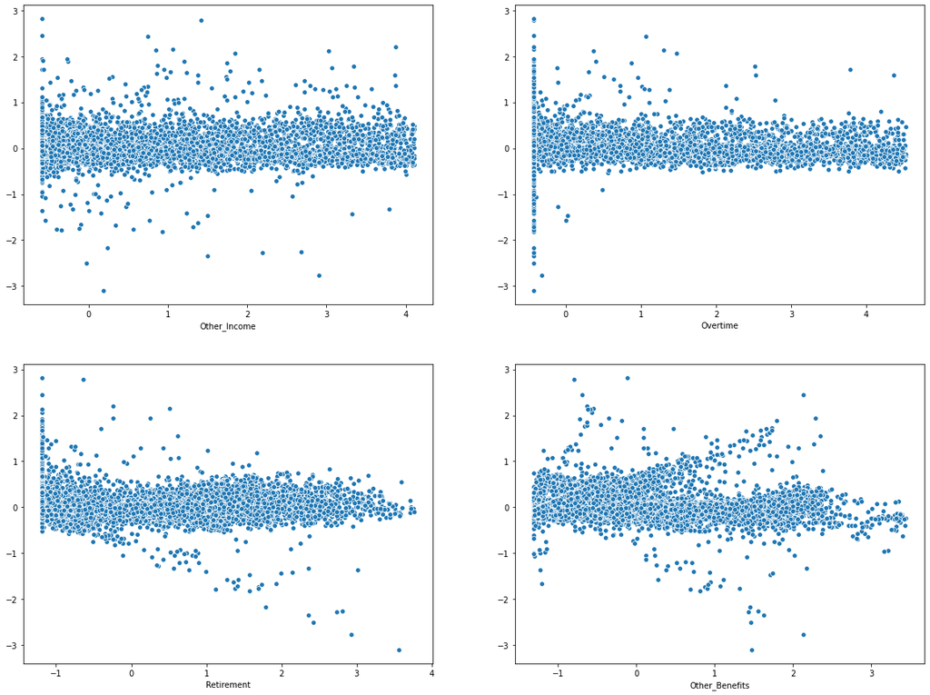

```python
# create subplots of scatter plots
# pass the number of rows in a subplot to 'nrows'
# pass the number of columns in a subplot to 'ncolumns'
# set plot size using 'figsize'
fig, ax = plt.subplots(nrows = 2, ncols= 2, figsize=(20, 15))

# use for loop to create scatter plot for residuals and each independent variable (do not consider the intercept)
# 'ax' assigns axes object to draw the plot onto
for variable, subplot in zip(X_train_signi_var.columns[1:5], ax.flatten()):
    sns.scatterplot(X_train_signi_var[variable], MLR_model_with_significant_var.resid , ax=subplot)

# display the plot
plt.show()
```

**Interpretation:** The above plots show no specific pattern, implies that there is a linearity present in the data.

### 5.3.2 Autocorrelation

We can check the correlation between the residuals using the `Durbin-Watson` test. The value of the test statistic ranges from 0 to 4. The test statistic value near to 2, represents no autocorrelation. The value of the test statistic between 0 and 2 implies positive autocorrelation and the value between 2 and 4 implies negative autocorrelation.

Print the summary of the model with significant variables to check the autocorrelation.

```python
# print the model summary
print(MLR_model_with_significant_var.summary())
```

```
                             OLS Regression Results
===============================================================================
Dep. Variable:     Total_Reimbursement   R-squared:                       0.962
Model:                             OLS   Adj. R-squared:                  0.962
Method:                  Least Squares   F-statistic:                 9.392e+04
Date:                 Fri, 16 Oct 2020   Prob (F-statistic):               0.00
Time:                         15:59:00   Log-Likelihood:                 5494.8
No. Observations:                26320   AIC:                        -1.097e+04
Df Residuals:                    26312   BIC:                        -1.091e+04
Df Model:                            7
Covariance Type:             nonrobust
==================================================================================
                     coef    std err          t      P>|t|      [0.025      0.975]
----------------------------------------------------------------------------------
const             -0.0444      0.002    -19.797      0.000      -0.049      -0.040
Other_Income       0.0563      0.001     42.860      0.000       0.054       0.059
Overtime           0.0161      0.001     12.691      0.000       0.014       0.019
Retirement         0.7582      0.002    309.332      0.000       0.753       0.763
Other_Benefits     0.2300      0.002     96.798      0.000       0.225       0.235
Year_2016          0.1125      0.004     29.036      0.000       0.105       0.120
Year_2017          0.0989      0.003     30.512      0.000       0.093       0.105
Year_2018          0.0019      0.003      0.597      0.551      -0.004       0.008
==============================================================================
Omnibus:                    12762.143   Durbin-Watson:                   1.965
Prob(Omnibus):                  0.000   Jarque-Bera (JB):           939475.220
Skew:                           1.479   Prob(JB):                         0.00
Kurtosis:                      32.119   Cond. No.                         6.03
==============================================================================

Warnings:
[1] Standard Errors assume that the covariance matrix of the errors is correctly specified.
```

**Interpretation:** From the above summary, we can observe that the value obtained from the `Durbin-Watson` test statistic is close to 2 (= 1.965). Thus, we conclude that there is no autocorrelation.

### 5.3.3 Heteroskedasticity

If the residuals have constant variance across different values of the predicted values, then it is known as `Homoskedasticity`. The absence of homoskedasticity is known as, heteroskedasticity. One of the assumptions of linear regression is that heteroskedasticity should not be present. Let us study two different tests to check the presence of heteroskedasticity.

Breusch-Pagan is one of the tests for detecting heteroskedasticity in the residuals.  
The test hypothesis for the Breusch-Pagan test is given as:

**H<sub>o</sub>: There is homoscedasticity present in the data**

**H<sub>1</sub>: There is a heteroscedasticity present in the data**

```python
# create vector of result parmeters
name = ['f-value','p-value']

# perform Breusch-Pagan test using residuals and independent variables
# compute residuals using 'resid'
# 'exog' returns the independent variables in the model alng with the intercept
test = sms.het_breuschpagan(MLR_model_with_significant_var.resid, MLR_model_with_significant_var.model.exog)

# print the output
# use 'lzip' to zip the column names and test results
# use 'test[2:]' to retrieve the F-statistic and its corresponding p-value
lzip(name, test[2:])
```

```
[('f-value', 92.09052954865287), ('p-value', 2.711234115975642e-133)]
```

**Interpretation:** We observe that the p-value is less than 0.05; thus, we conclude that there is heteroskedasticity present in the data.

### 5.3.4 Tests for Normality

As per the assumptions of linear regression, residuals should be normally distributed. If the target variable is normally distributed then the residuals are also normally distributed, thus we check the normality only for the target variable.

#### 1. Q-Q Plot

Q-Q plot is s visualization technique to check the normality of the residuals. It plots the quantiles of observed data versus the quantiles of the standard normal distribution.

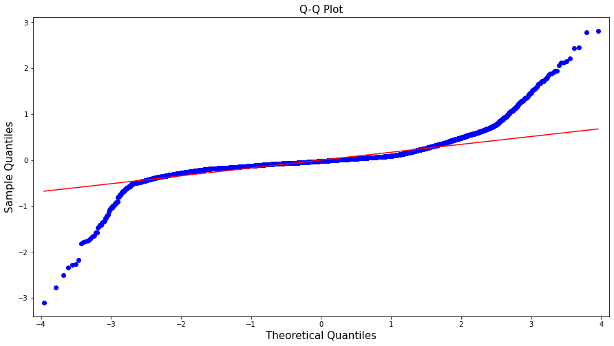

```python
# set the plot size using 'rcParams'
# once the plot size is set using 'rcParams', it sets the size of all the forthcoming plots in the file
# pass width and height in inches to 'figure.figsize'
plt.rcParams['figure.figsize'] = [15,8]

# plot the Q-Q plot
# 'r' represents the regression line
qqplot(MLR_model_with_significant_var.resid, line = 'r')

# set plot and axes labels
# set text size using 'fontsize'
plt.title('Q-Q Plot', fontsize = 15)
plt.xlabel('Theoretical Quantiles', fontsize = 15)
plt.ylabel('Sample Quantiles', fontsize = 15)

# display the plot
plt.show()
```

**Interpretation:** The diagonal line (red line) is the regression line and the blue points are the cumulative distribution of the residuals. As some of the points are away from the diagonal line, we conclude that the residuals do not follow a `normal distribution`.

#### 2. Shapiro Wilk Test

The Shapiro Wilk test is used to check the normality of the residuals. The test hypothesis is given as:

**H<sub>o</sub>: Residuals are normally distributed**

**H<sub>1</sub>: Residuals are not normally distributed**

```python
# perform Shapiro Wilk test using 'shapiro()' from scipy library
# shapiro() returns a tuple having the values of test statistics and the corresponding p-value
# 'resid' returns the residuals in the model
# pass the residuals to 'shapiro()'
stat, p_value = shapiro(MLR_model_with_significant_var.resid)

# print the test statistic and corresponding p-value
print('Test statistic:', stat)
print('P-Value:', p_value)
```

```
Test statistic: 0.7611103057861328
P-Value: 0.0
```

**Interpretation:** From the above test we can see that the p-value is 0.0 (less than 0.05), thus we can say that the residuals are not normally distributed.

# 6. Model Evaluation

In this section, we evaluate the model containing significant variables.

Let us print the summary of the multiple regression model.

```python
# print the model summary
print(MLR_model_with_significant_var.summary())
```

```
                             OLS Regression Results
===============================================================================
Dep. Variable:     Total_Reimbursement   R-squared:                       0.962
Model:                             OLS   Adj. R-squared:                  0.962
Method:                  Least Squares   F-statistic:                 9.392e+04
Date:                 Fri, 16 Oct 2020   Prob (F-statistic):               0.00
Time:                         15:59:00   Log-Likelihood:                 5494.8
No. Observations:                26320   AIC:                        -1.097e+04
Df Residuals:                    26312   BIC:                        -1.091e+04
Df Model:                            7
Covariance Type:             nonrobust
==================================================================================
                     coef    std err          t      P>|t|      [0.025      0.975]
----------------------------------------------------------------------------------
const             -0.0444      0.002    -19.797      0.000      -0.049      -0.040
Other_Income       0.0563      0.001     42.860      0.000       0.054       0.059
Overtime           0.0161      0.001     12.691      0.000       0.014       0.019
Retirement         0.7582      0.002    309.332      0.000       0.753       0.763
Other_Benefits     0.2300      0.002     96.798      0.000       0.225       0.235
Year_2016          0.1125      0.004     29.036      0.000       0.105       0.120
Year_2017          0.0989      0.003     30.512      0.000       0.093       0.105
Year_2018          0.0019      0.003      0.597      0.551      -0.004       0.008
==============================================================================
Omnibus:                    12762.143   Durbin-Watson:                   1.965
Prob(Omnibus):                  0.000   Jarque-Bera (JB):           939475.220
Skew:                           1.479   Prob(JB):                         0.00
Kurtosis:                      32.119   Cond. No.                         6.03
==============================================================================

Warnings:
[1] Standard Errors assume that the covariance matrix of the errors is correctly specified.
```

## 6.1 R-Squared

The coefficient of determination explains the percentage of variation in the dependent variable that the independent variables explain collectively.

```python
# calculate R-Squared on train dataset
# use 'rsquared' from statsmodel
r_sq_mlr = MLR_model_with_significant_var.rsquared

# print the value
r_sq_mlr
```

```
0.9615185828120318
```

## 6.2 Adjusted R-Squared

It explains the percentage of variation by the independent variables that affect the target variable. The value of adjusted R-squared is always less than R-squared.

```python
# calculate adjusted R-Squared on train dataset
# use 'rsquared_adj' from statsmodel
adj_r_sq = MLR_model_with_significant_var.rsquared_adj

# print the value
adj_r_sq
```

```
0.9615083452808554
```

Now, we can also calculate the adjusted R-Squared value using the formula **1 - (((1 - R-Squared) * (n - 1)) / (n - k - 1))**.

Where,  
k: Number of beta coefficients  
n: Total number of observations

```python
# calculate adjusted R-Squared on train dataset using the formula
# 'n' denotes total number of observations
n = len(X_train_signi_var)

# 'k' denotes number of predictors (including the intercept)
k = len(X_train_signi_var.columns)

# calculate adjusted R-squared
# 'r_sq_mlr' represents the R-Squared value
adj_r_sq = 1 - (((1 - r_sq_mlr) * (n - 1)) / (n - k - 1))

# print the value
adj_r_sq
```

```
0.9615068823317193
```

**Interpretation:** We can see that the value of adjusted R-squared calculated using the formula and the one obtained from the model are nearly same. We can also obtain this value from the summary of the model.

## 6.3 Overall F-Test & p-value of the Model

F-test is used to checking whether the overall regression model is statistically significant or not. The F-statistic is given as:

**f_value = (R-squared / (k-1)) / ((1- R-squared) / n - k)**

Where,

k: Number of beta coefficients  
n: Total number of observations

The test hypothesis for F-test is given as:

**H<sub>o</sub>: All β's are equal to zero** (i.e. regression model is not significant)

**H<sub>1</sub>: At least one β is not equal to zero** (i.e. regression model is significant)

```python
# compute f_value using the below formula
# f_value = (r_sq / k-1)/((1- r_sq)/n-k)

# k = number of beta coefficients
k = len(X_train_signi_var.columns)

# n = number of observations
n = len(X_train_signi_var)

# calculate value of F-statistic
# 'r_sq_mlr' represents the R-Squared value
f_value = (r_sq_mlr / (k - 1))/((1-r_sq_mlr)/(n - k))

# print the value
f_value
```

```
93920.94307074857
```

We can also obtain this value from the summary of the model.

Now, calculate the corresponding p-value for F-statistic.

```python
# calculate p-value for F-statistic
# use 'sf' (Survival function) from f-distribution to calculate the corresponding p-value

# degrees of freedom
# dfn = k-1 = 6-1 = 5
# dfd = n-k = 1043-5 = 1038
p_val = stats.f.sf(f_value, dfn = 5, dfd = 1038)

# print the value
p_val
```

```
0.0
```

**Interpretation:** As, the p-value is less than 0.05, we accept the alternate hypothesis; i.e. the model is significant.

# 7. Model Performance

#### Let us do some predictions using the train and test dataset.

```python
# For training set:
# train_pred: prediction made by the model on the training dataset 'X_train_signi_var'
# y_train_signi_var: actual values of the target variable for the train dataset

# For testing set:
# test_pred: prediction made by the model on the test dataset 'X_test_signi_var'
# y_test_signi_var: actual values of the target variable for the test dataset

# predict the output of the target variable from the train data
# train_pred can also be obtained from "MLR_model_with_significant_var.fittedvalues"
train_pred = MLR_model_with_significant_var.predict(X_train_signi_var)

# predict the output of the target variable from the test data
test_pred = MLR_model_with_significant_var.predict(X_test_signi_var)
```

## 7.1 Mean Squared Error (MSE)

It is defined as the average squared difference between the actual and predicted values.

```python
# calculate the MSE using the "mean_squared_error" function

# calculate the MSE for the train data
# round the value upto 4 digits using 'round()'
mse_train = round(mean_squared_error(y_train_signi_var, train_pred),4)

# print the MSE for the training set
print("Mean Squared Error (MSE) on training set: ", mse_train)

# calculate the MSE for the test data
# round the value upto 4 digits using 'round()'
mse_test = round(mean_squared_error(y_test_signi_var, test_pred),4)

# print the MSE for the test set
print("Mean Squared Error (MSE) on test set: ", mse_test)
```

```
Mean Squared Error (MSE) on training set:  0.0386
Mean Squared Error (MSE) on test set:  0.0369
```

## 7.2 Root Mean Squared Error (RMSE)

It is defined as the square root of MSE. Lower the value of RMSE, better is the fit of the regression line.

```python
# calculate the MSE using the "mean_squared_error" function

# MSE for the train data
mse_train = mean_squared_error(y_train_signi_var, train_pred)

# take the square root of the MSE to calculate the RMSE
# round the value upto 4 digits using 'round()'
rmse_train = round(np.sqrt(mse_train), 4)

# print the RMSE for the train set
print("Root Mean Squared Error (RMSE) on training set: ", rmse_train)

# MSE for the test data
mse_test = mean_squared_error(y_test_signi_var, test_pred)

# take the square root of the MSE to calculate the RMSE
# round the value upto 4 digits using 'round()'
rmse_test = round(np.sqrt(mse_test), 4)

# print the RMSE for the test set
print("Root Mean Squared Error (RMSE) on test set: ", rmse_test)
```

```
Root Mean Squared Error (RMSE) on training set:  0.1964
Root Mean Squared Error (RMSE) on test set:  0.192
```

## 7.3 Mean Absolute Error (MAE)

It is defined as the average of the absolute difference between the actual and predicted values.

```python
# calculate the MAE using the "mean_absolute_error" function

# calculate the MAE for the train data
# round the value upto 4 digits using 'round()'
mae_train = round(mean_absolute_error(y_train_signi_var, train_pred),4)

# print the MAE for the training set
print("Mean Absolute Error (MAE) on training set: ", mae_train)

# calculate the MAE for the test data
# round the value upto 4 digits using 'round()'
mae_test = round(mean_absolute_error(y_test_signi_var, test_pred),4)

# print the MAE for the test set
print("Mean Absolute Error (MAE) on test set: ", mae_test)
```

```
Mean Absolute Error (MAE) on training set:  0.1159
Mean Absolute Error (MAE) on test set:  0.1161
```

## 7.4 Mean Absolute Percentage Error (MAPE)

It is used to measure the accuracy of the model as a percentage. We define a function to calculate MAPE for training and test dataset.

```python
# define a function to calculate MAPE
# pass the actual and predicted values as input to the function
# return the calculated MAPE
def mape(actual, predicted):
    return (np.mean(np.abs((actual - predicted) / actual)) * 100)
```

```python
# calculate the mape using the "mape()" function created above

# calculate the MAPE for the train data
# round the value upto 4 digits using 'round()'
mape_train = round(mape(y_train_signi_var, train_pred),4)

# print the MAPE for the training set
print("Mean Absolute Percentage Error (MAPE) on training set: ", mape_train)

# calculate the MAPE for the test data
# round the value upto 4 digits using 'round()'
mape_test = round(mape(y_test_signi_var, test_pred),4)

# print the MAPE for the test set
print("Mean Absolute Percentage Error (MAPE) on test set: ", mape_test)
```

```
Mean Absolute Percentage Error (MAPE) on training set:  166.5083
Mean Absolute Percentage Error (MAPE) on test set:  48.902
```

# 8. Compare Model Performances

Let us compare the model performance metrics (MSE, RMSE, MAE, MAPE) for `MLR_full_model`, `MLR_model_with_significant_var` and `MLR_interaction_model` to find the best model.

```python
# create the table for all the model performance metrics
# metrics considered for model comparision are MSE, RMSE, MAE and MAPE
# create a list of column names
cols = ['Model_Name', 'R-squared', 'Adj. R-squared', 'MSE', 'RMSE', 'MAE', 'MAPE']

# creating a empty dataframe of the colums
result_table = pd.DataFrame(columns = cols)
```

Now, calculate performance measure for `MLR_full_model`

```python
# calculate R-squared, Adjusted R-squared, MSE, RMSE, MAE and MAPE for full model
# use 'rsquared' to calculate R-squared value
# use 'rsquared_adj' to calculate Adjusted R-squared value
# use 'mean_squared_error' to calculate MSE
# use 'rmse' to calculate RMSE
# use 'mean_absolute_error' to calculate MAE
# use the defined function 'mape' to calculate MAPE
MLR_full_model_metrics = pd.Series({'Model_Name': "MLR Full Model",
                     'R-squared': MLR_full_model.rsquared,
                     'Adj. R-squared': MLR_full_model.rsquared_adj,
                     'MSE': mean_squared_error(y_test_full, y_pred_full),
                     'RMSE': rmse(y_test_full, y_pred_full),
                     'MAE': mean_absolute_error(y_test_full, y_pred_full),
                     'MAPE': mape(y_test_full, y_pred_full)
                   })

# append the values to the result table
result_table = result_table.append(MLR_full_model_metrics, ignore_index = True)

# print the result table
result_table
```

|  | Model_Name | R-squared | Adj. R-squared | MSE | RMSE | MAE | MAPE |
| --- | --- | --- | --- | --- | --- | --- | --- |
| 0 | MLR Full Model | 1.000000 | 1.000000 | 0.000000 | 0.000000 | 0.000000 | 0.000000 |

Now, calculate performance measure for `MLR_model_with_significant_var`

```python
# calculate R-squared, Adjusted R-squared, MSE, RMSE, MAE and MAPE for model with significant variables
# use 'rsquared' to calculate R-squared value
# use 'rsquared_adj' to calculate Adjusted R-squared value
# use 'mean_squared_error' to calculate MSE
# use 'rmse' to calculate RMSE
# use 'mean_absolute_error' to calculate MAE
# use the defined function 'mape' to calculate MAPE
MLR_model_signi_var_metrics = pd.Series({'Model_Name': "MLR Model with Significant Variables",
                     'R-squared': MLR_model_with_significant_var.rsquared,
                     'Adj. R-squared': MLR_model_with_significant_var.rsquared_adj,
                     'MSE': mean_squared_error(y_test_signi_var, y_pred_signi_var),
                     'RMSE': rmse(y_test_signi_var, y_pred_signi_var),
                     'MAE': mean_absolute_error(y_test_signi_var, y_pred_signi_var),
                     'MAPE': mape(y_test_signi_var, y_pred_signi_var)
                   })

# append the values to the result table
result_table = result_table.append(MLR_model_signi_var_metrics, ignore_index = True)

# print the result table
result_table
```

|  | Model_Name | R-squared | Adj. R-squared | MSE | RMSE | MAE | MAPE |
| --- | --- | --- | --- | --- | --- | --- | --- |
| 0 | MLR Full Model | 1.000000 | 1.000000 | 0.000000 | 0.000000 | 0.000000 | 0.000000 |
| 1 | MLR Model with Significant Variables | 0.961519 | 0.961508 | 0.036854 | 0.191973 | 0.116095 | 48.902005 |

Now, calculate the performance measures for `MLR_model_with_interaction`

```python
# calculate R-squared, Adjusted R-squared, MSE, RMSE, MAE and MAPE for model with interaction
# use 'rsquared' to calculate R-squared value
# use 'rsquared_adj' to calculate Adjusted R-squared value
# use 'mean_squared_error' to calculate MSE
# use 'rmse' to calculate RMSE
# use 'mean_absolute_error' to calculate MAE
# use the defined function 'mape' to calculate MAPE
MLR_model_interaction_metrics = pd.Series({'Model_Name': "MLR Model with Interaction",
                     'R-squared': MLR_model_with_interaction.rsquared,
                     'Adj. R-squared': MLR_model_with_interaction.rsquared_adj,
                     'MSE': mean_squared_error(y_test_inter, y_pred_inter),
                     'RMSE': rmse(y_test_inter, y_pred_inter),
                     'MAE': mean_absolute_error(y_test_inter, y_pred_inter),
                     'MAPE': mape(y_test_inter, y_pred_inter)
                   })

# append the values to the result table
result_table = result_table.append(MLR_model_interaction_metrics, ignore_index = True)

# print the result table
result_table
```

|  | Model_Name | R-squared | Adj. R-squared | MSE | RMSE | MAE | MAPE |
| --- | --- | --- | --- | --- | --- | --- | --- |
| 0 | MLR Full Model | 1.000000 | 1.000000 | 0.000000 | 0.000000 | 0.000000 | 0.000000 |
| 1 | MLR Model with Significant Variables | 0.961519 | 0.961508 | 0.036854 | 0.191973 | 0.116095 | 48.902005 |
| 2 | MLR Model with Interaction | 0.963366 | 0.963355 | 0.035816 | 0.189251 | 0.111485 | 49.726058 |

**Interpretation:** The R-Squared and the Adj. R-Squared for the full model (=1) indicates that the model perfectly fits the data which is not practical and also the model is likely to overfit. Thus, MLR Full Model cannot be considered as the best model.

Overfitting occurs when a model learns the detail and noise in the training data to the extent that it adversely impacts the model's performance on the new data. We will learn about overfitting in the upcoming portion.

On the other hand, R-Squared and the Adj. R-Squared for the MLR Model with Interaction is more than the MLR Model with Significant Variables. Also, the RMSE value for the MLR Model with Interaction is less as compared to that of MLR Model with Significant Variables.  
Thus, we can say that the MLR Model with Interaction is the best model.